# Using ABACAB and KU-UNC as example for analyses discussed in 525

# Statistical analyses

The next sections include code for running most of the analyses you see commonly in Psychology statistic courses or in student projects. The choice of the analysis depends on a combination of your research question and the level of measurement of your variables (especially nominal/categorical vs dimensional-ish).

You may need to check some additional assumptions depending on your choice of analysis.

These examples would be places to look for “Chunk 7 – run analyses,” and also maybe more checking assumptions (augmenting what we get from psych::describe and psych::pairs.panels). There are some examples of prototypes for presentation quality figures with ggplot2, as well.

# Correlations

Remember to check assumptions – are the variables continuous? If yes, are they normally distributed?

If one or both of the variables are *not* normally distributed, then switch to Spearman’s rho instead of the usual Pearson’s r.

pairs.panels and describe are a good combination to check these. boxplots are a quick visual check for univariate outliers.

```r
psych::corr.test(modelvars)
```

```
## Call:psych::corr.test(x = modelvars)
## Correlation matrix
##          cmrsptot pgbsleep bpvsall anyadhd agechild cgender cgroup5
## cmrsptot     1.00     0.54    0.37    0.32    -0.17   -0.05   -0.37
## pgbsleep     0.54     1.00    0.29    0.05     0.10    0.07   -0.36
## bpvsall      0.37     0.29    1.00    0.03     0.00    0.06   -0.79
## anyadhd      0.32     0.05    0.03    1.00    -0.30   -0.27   -0.06
## agechild    -0.17     0.10    0.00   -0.30     1.00    0.20   -0.13
## cgender     -0.05     0.07    0.06   -0.27     0.20    1.00   -0.13
## cgroup5     -0.37    -0.36   -0.79   -0.06    -0.13   -0.13    1.00
## Sample Size
## [1] 542
## Probability values (Entries above the diagonal are adjusted for multiple tests.)
##          cmrsptot pgbsleep bpvsall anyadhd agechild cgender cgroup5
## cmrsptot     0.00     0.00    0.00    0.00     0.00    1.00    0.00
## pgbsleep     0.00     0.00    0.00    1.00     0.16    0.79    0.00
## bpvsall      0.00     0.00    0.00    1.00     1.00    0.96    0.00
## anyadhd      0.00     0.27    0.42    0.00     0.00    0.00    0.96
## agechild     0.00     0.02    0.92    0.00     0.00    0.00    0.03
## cgender      0.28     0.11    0.16    0.00     0.00    0.00    0.03
## cgroup5      0.00     0.00    0.00    0.17     0.00    0.00    0.00
##
##  To see confidence intervals of the correlations, print with the short=FALSE option
```

```r
psych::corr.test(modelvars, method="spearman") %>% print(digits=3)#Default is Pearson; also does Kendall Tau
```

```
## Call:psych::corr.test(x = modelvars, method = "spearman")
## Correlation matrix
##          cmrsptot pgbsleep bpvsall anyadhd agechild cgender cgroup5
## cmrsptot    1.000    0.527   0.360   0.338   -0.161  -0.059  -0.352
## pgbsleep    0.527    1.000   0.308   0.056    0.095   0.063  -0.399
## bpvsall     0.360    0.308   1.000   0.035    0.006   0.061  -0.727
## anyadhd     0.338    0.056   0.035   1.000   -0.300  -0.267  -0.031
## agechild   -0.161    0.095   0.006  -0.300    1.000   0.204  -0.149
## cgender    -0.059    0.063   0.061  -0.267    0.204   1.000  -0.132
## cgroup5    -0.352   -0.399  -0.727  -0.031   -0.149  -0.132   1.000
## Sample Size
## [1] 542
## Probability values (Entries above the diagonal are adjusted for multiple tests.)
##          cmrsptot pgbsleep bpvsall anyadhd agechild cgender cgroup5
## cmrsptot    0.000    0.000   0.000   0.000    0.002   0.988   0.000
## pgbsleep    0.000    0.000   0.000   0.988    0.215   0.988   0.000
## bpvsall     0.000    0.000   0.000   1.000    1.000   0.988   0.000
## anyadhd     0.000    0.191   0.418   0.000    0.000   0.000   1.000
## agechild    0.000    0.027   0.898   0.000    0.000   0.000   0.005
## cgender     0.173    0.141   0.159   0.000    0.000   0.000   0.019
## cgroup5     0.000    0.000   0.000   0.466    0.000   0.002   0.000
##
##  To see confidence intervals of the correlations, print with the short=FALSE option
```

```r
cor.mat <- modelvars %>% cor_mat() #table of coefficients (Pearson as default)
cor.mat
```

|  | rowname | cmrsptot | pgbsleep | bpvsall | anyadhd | agechild | cgender | cgroup5 |
| --- | --- | --- | --- | --- | --- | --- | --- | --- |
| 1 | cmrsptot | 1.000 | 0.540 | 0.3700 | 0.320 | -0.1700 | -0.046 | -0.370 |
| 2 | pgbsleep | 0.540 | 1.000 | 0.2900 | 0.047 | 0.1000 | 0.068 | -0.360 |
| 3 | bpvsall | 0.370 | 0.290 | 1.0000 | 0.035 | 0.0042 | 0.061 | -0.790 |
| 4 | anyadhd | 0.320 | 0.047 | 0.0350 | 1.000 | -0.3000 | -0.270 | -0.059 |
| 5 | agechild | -0.170 | 0.100 | 0.0042 | -0.300 | 1.0000 | 0.200 | -0.130 |
| 6 | cgender | -0.046 | 0.068 | 0.0610 | -0.270 | 0.2000 | 1.000 | -0.130 |
| 7 | cgroup5 | -0.370 | -0.360 | -0.7900 | -0.059 | -0.1300 | -0.130 | 1.000 |

```r
cor.mat %>% cor_get_pval() #table of p values
```

| rowname | cmrsptot | pgbsleep | bpvsall | anyadhd | agechild | cgender | cgroup5 |
| --- | --- | --- | --- | --- | --- | --- | --- |
| cmrsptot | 0.00e+00 | 1.00e-42 | 7.54e-19 | 1.75e-14 | 6.33e-05 | 2.80e-01 | 2.04e-19 |
| pgbsleep | 1.00e-42 | 0.00e+00 | 1.12e-11 | 2.75e-01 | 1.99e-02 | 1.14e-01 | 1.84e-18 |
| bpvsall | 7.54e-19 | 1.12e-11 | 0.00e+00 | 4.18e-01 | 9.23e-01 | 1.59e-01 | 2.49e-116 |
| anyadhd | 1.75e-14 | 2.75e-01 | 4.18e-01 | 0.00e+00 | 9.31e-13 | 2.55e-10 | 1.72e-01 |
| agechild | 6.33e-05 | 1.99e-02 | 9.23e-01 | 9.31e-13 | 0.00e+00 | 1.49e-06 | 3.51e-03 |
| cgender | 2.80e-01 | 1.14e-01 | 1.59e-01 | 2.55e-10 | 1.49e-06 | 0.00e+00 | 3.25e-03 |
| cgroup5 | 2.04e-19 | 1.84e-18 | 2.49e-116 | 1.72e-01 | 3.51e-03 | 3.25e-03 | 0.00e+00 |

```r
cor.mat %>%
  cor_as_symbols() %>%
  pull_lower_triangle() #triangle of asterisks
```

|  | rowname | cmrsptot | pgbsleep | bpvsall | anyadhd | agechild | cgender | cgroup5 |
| --- | --- | --- | --- | --- | --- | --- | --- | --- |
| 1 | cmrsptot |  |  |  |  |  |  |  |
| 2 | pgbsleep | + |  |  |  |  |  |  |
| 3 | bpvsall | . | . |  |  |  |  |  |
| 4 | anyadhd | . |  |  |  |  |  |  |
| 5 | agechild |  |  |  | . |  |  |  |
| 6 | cgender |  |  |  | . |  |  |  |
| 7 | cgroup5 | . | . | * |  |  |  |  |

# Regression analyses using psych package

## Checklist for regression analysis ###Dependent variable * Is your dependent variable continuous?

(If it’s a categorical variable with two options, consider logistic regression instead) * Is your DV normally distributed (more or less) - Skew and Kurtosis < |3| - no extreme outliers in boxplot - If not, would a transformation fix?

- Predictors If dimensional, also check for outliers and skew, kurtosis as above (though normality is less crucial for predictor – but look out for outliers! They can be “high leverage” like in that Anscomb Quartet scatterplot example) If they are categorical, are they already dummy coded? If not, use as.factor() and R will dummy code them for us! (also possible to pick which group is the comparison group)

```r
basic<-setCor(cmrsptot~ bpvsall+anyadhd+agechild, data=modelvars, std=TRUE)
```

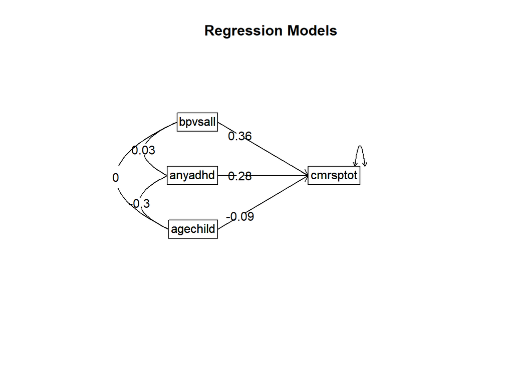

```r
plot(basic)
summary(basic)
```

```
##
## Multiple Regression from raw data
## setCor(y = cmrsptot ~ bpvsall + anyadhd + agechild, data = modelvars,
##     std = TRUE)
##
## Multiple Regression from matrix input
##
## Beta weights
##             cmrsptot
## (Intercept)    0.000
## bpvsall        0.359
## anyadhd        0.283
## agechild      -0.088
##
## Multiple R
## cmrsptot
##     0.49
##
## Multiple R2
## cmrsptot
##     0.24
##
## Cohen's set correlation R2
## [1] 0.24
##
## Squared Canonical Correlations
## NULL
```

```r
basic
```

```
## Call: setCor(y = cmrsptot ~ bpvsall + anyadhd + agechild, data = modelvars,
##     std = TRUE)
##
## Multiple Regression from raw data
##
##  DV =  cmrsptot
##             slope   se     t       p lower.ci upper.ci VIF Vy.x
## (Intercept)  0.00 0.04  0.00 1.0e+00    -0.07     0.07 1.0 0.00
## bpvsall      0.36 0.04  9.52 5.6e-20     0.28     0.43 1.0 0.13
## anyadhd      0.28 0.04  7.15 2.8e-12     0.20     0.36 1.1 0.09
## agechild    -0.09 0.04 -2.22 2.7e-02    -0.17    -0.01 1.1 0.01
##
## Residual Standard Error =  0.88  with  538  degrees of freedom
##
##  Multiple Regression
##             R   R2  Ruw R2uw Shrunken R2 SE of R2 overall F df1 df2        p
## cmrsptot 0.49 0.24 0.33 0.11        0.23     0.03        56   3 538 1.68e-31
```

## Collinearity in regression

```r
book<-setCor(lbhagb9~despa+ desna+ deshost+desnanod, data=abacab, std=TRUE)
```

```
## In smc, smcs > 1 were set to 1.0
```

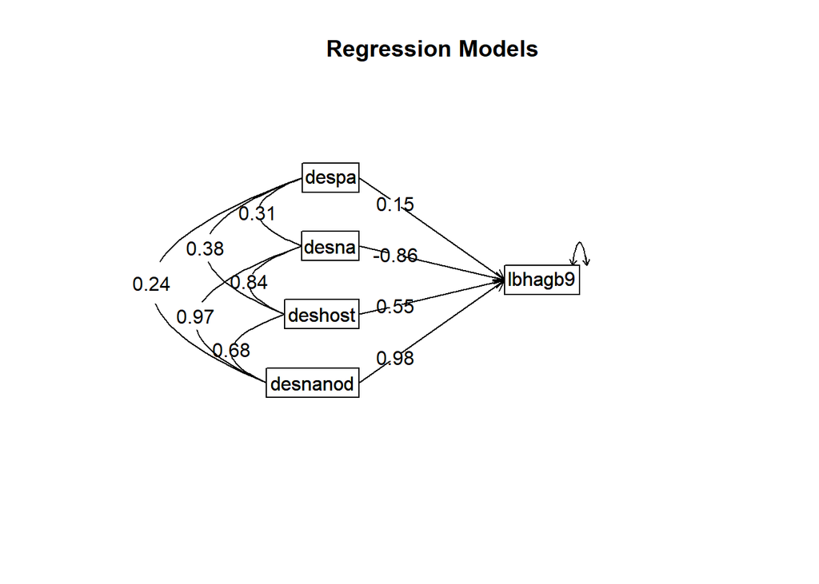

```r
plot(book)
summary(book)
```

```
##
## Multiple Regression from raw data
## setCor(y = lbhagb9 ~ despa + desna + deshost + desnanod, data = abacab,
##     std = TRUE)
##
## Multiple Regression from matrix input
##
## Beta weights
##             lbhagb9
## (Intercept)    0.00
## despa          0.15
## desna         -0.86
## deshost        0.55
## desnanod       0.98
##
## Multiple R
## lbhagb9
##    0.62
##
## Multiple R2
## lbhagb9
##    0.38
##
## Cohen's set correlation R2
## [1] 0.38
##
## Squared Canonical Correlations
## NULL
```

```r
book
```

```
## Call: setCor(y = lbhagb9 ~ despa + desna + deshost + desnanod, data = abacab,
##     std = TRUE)
##
## Multiple Regression from raw data
##
##  DV =  lbhagb9
##             slope   se    t       p lower.ci upper.ci  VIF  Vy.x
## (Intercept)  0.00 0.03 0.00 1.0e+00    -0.05     0.05 1.00  0.00
## despa        0.15 0.03 5.08 4.6e-07     0.09     0.21 1.17  0.05
## desna       -0.86  NaN  NaN     NaN      NaN      NaN  Inf -0.51
## deshost      0.55  NaN  NaN     NaN      NaN      NaN  Inf  0.30
## desnanod     0.98  NaN  NaN     NaN      NaN      NaN  Inf  0.55
##
## Residual Standard Error =  0.79  with  823  degrees of freedom
##
##  Multiple Regression
##            R   R2  Ruw R2uw Shrunken R2 SE of R2 overall F df1 df2       p
## lbhagb9 0.62 0.38 0.62 0.38        0.38     0.03       128   4 823 3.7e-85
```

The colon or *sets up the interaction effect for you (no manual construction of the interaction term) ##Interaction (aka moderation) in regression

```r
eayInt<-setCor(cmrsptot~bpvsall*anyadhd+agechild, data=modelvars, std=TRUE)
```

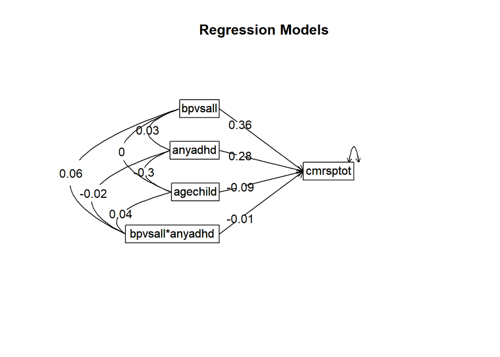

```r
plot(eayInt)
summary(eayInt)
```

```
##
## Multiple Regression from raw data
## setCor(y = cmrsptot ~ bpvsall * anyadhd + agechild, data = modelvars,
##     std = TRUE)
##
## Multiple Regression from matrix input
##
## Beta weights
##                 cmrsptot
## (Intercept)       0.0000
## bpvsall           0.3591
## anyadhd           0.2824
## agechild         -0.0874
## bpvsall*anyadhd  -0.0058
##
## Multiple R
## cmrsptot
##     0.49
##
## Multiple R2
## cmrsptot
##     0.24
##
## Cohen's set correlation R2
## [1] 0.24
##
## Squared Canonical Correlations
## NULL
```

```r
eayInt
```

```
## Call: setCor(y = cmrsptot ~ bpvsall * anyadhd + agechild, data = modelvars,
##     std = TRUE)
##
## Multiple Regression from raw data
##
##  DV =  cmrsptot
##                 slope   se     t       p lower.ci upper.ci  VIF Vy.x
## (Intercept)      0.00 0.04  0.00 1.0e+00    -0.07     0.07 1.00 0.00
## bpvsall          0.36 0.04  9.51 6.3e-20     0.28     0.43 1.00 0.13
## anyadhd          0.28 0.04  7.15 2.9e-12     0.20     0.36 1.10 0.09
## agechild        -0.09 0.04 -2.21 2.8e-02    -0.17    -0.01 1.10 0.01
## bpvsall*anyadhd -0.01 0.04 -0.15 8.8e-01    -0.08     0.07 1.01 0.00
##
## Residual Standard Error =  0.88  with  537  degrees of freedom
##
##  Multiple Regression
##             R   R2  Ruw R2uw Shrunken R2 SE of R2 overall F df1 df2        p
## cmrsptot 0.49 0.24 0.27 0.08        0.23     0.03      41.9   4 537 1.36e-30
```

Note: In psychology we would not include a 3-way interaction without also including all of the 2-way interactions underneath it.

```r
eay3way<-setCor(cmrsptot~(bpvsall:anyadhd:agechild), data=modelvars, std=TRUE)
```

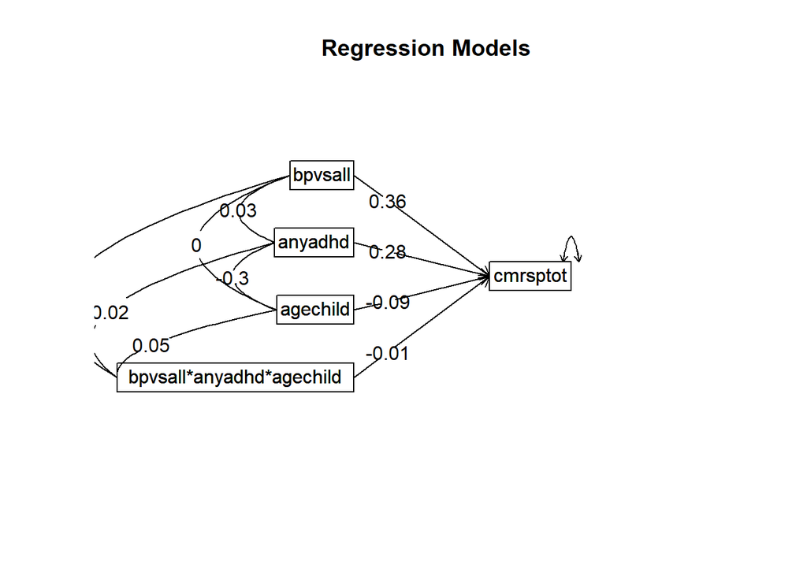

```r
plot(eay3way)
eay3way
```

```
## Call: setCor(y = cmrsptot ~ (bpvsall:anyadhd:agechild), data = modelvars,
##     std = TRUE)
##
## Multiple Regression from raw data
##
##  DV =  cmrsptot
##                          slope   se     t       p lower.ci upper.ci  VIF Vy.x
## (Intercept)               0.00 0.04  0.00 1.0e+00    -0.07     0.07 1.00 0.00
## bpvsall                   0.36 0.04  9.24 5.9e-19     0.28     0.43 1.06 0.13
## anyadhd                   0.28 0.04  7.15 2.9e-12     0.20     0.36 1.10 0.09
## agechild                 -0.09 0.04 -2.21 2.8e-02    -0.17    -0.01 1.10 0.01
## bpvsall*anyadhd*agechild -0.01 0.04 -0.15 8.8e-01    -0.08     0.07 1.06 0.00
##
## Residual Standard Error =  0.88  with  537  degrees of freedom
##
##  Multiple Regression
##             R   R2  Ruw R2uw Shrunken R2 SE of R2 overall F df1 df2        p
## cmrsptot 0.49 0.24 0.24 0.06        0.23     0.03      41.9   4 537 1.36e-30
```

This would be the right way to run a model with a 3-way and all the 2-way interactions. Interaction models get complicated to interpret. I wouldn’t recommend pushing it all the way to a three way for class. But I wanted to give you an example so you could see what it would look like.

```r
threeway<-setCor(cmrsptot~(bpvsall*anyadhd*agechild), data=modelvars, std=TRUE)
```

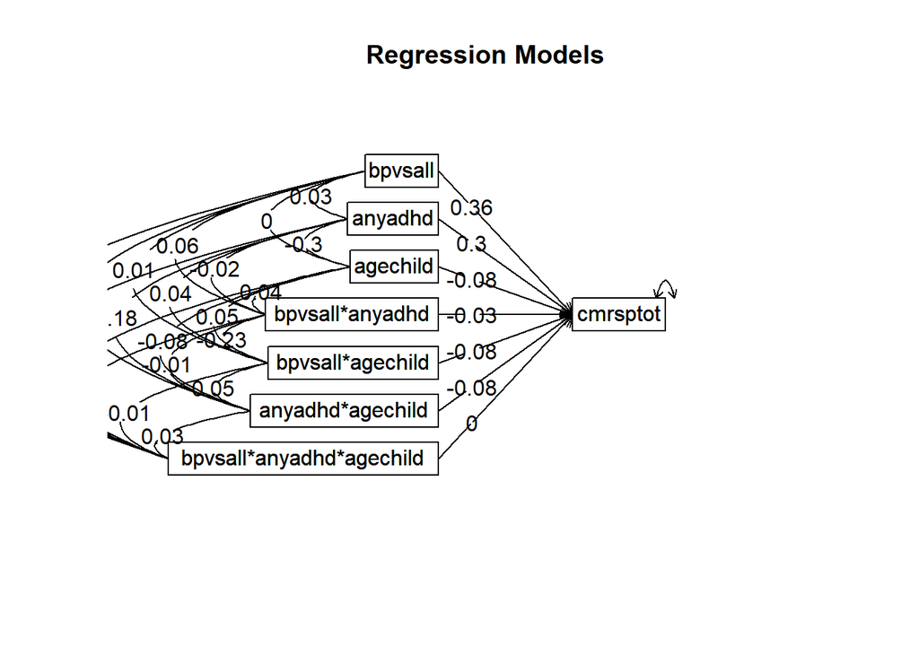

```r
plot(threeway)
threeway
```

```
## Call: setCor(y = cmrsptot ~ (bpvsall * anyadhd * agechild), data = modelvars,
##     std = TRUE)
##
## Multiple Regression from raw data
##
##  DV =  cmrsptot
##                          slope   se     t       p lower.ci upper.ci  VIF Vy.x
## (Intercept)               0.00 0.04  0.00 1.0e+00    -0.07     0.07 1.00 0.00
## bpvsall                   0.36 0.04  9.40 1.6e-19     0.29     0.44 1.07 0.13
## anyadhd                   0.30 0.04  7.53 2.2e-13     0.22     0.38 1.13 0.10
## agechild                 -0.08 0.04 -2.13 3.3e-02    -0.16    -0.01 1.11 0.01
## bpvsall*anyadhd          -0.03 0.04 -0.65 5.2e-01    -0.10     0.05 1.09 0.00
## bpvsall*agechild         -0.08 0.04 -2.08 3.8e-02    -0.16     0.00 1.07 0.01
## anyadhd*agechild         -0.08 0.04 -2.03 4.3e-02    -0.15     0.00 1.04 0.00
## bpvsall*anyadhd*agechild  0.00 0.04  0.03 9.7e-01    -0.08     0.08 1.09 0.00
##
## Residual Standard Error =  0.87  with  534  degrees of freedom
##
##  Multiple Regression
##            R   R2  Ruw R2uw Shrunken R2 SE of R2 overall F df1 df2        p
## cmrsptot 0.5 0.25 0.14 0.02        0.24     0.03      25.5   7 534 4.53e-30
```

```r
summary(threeway)
```

```
##
## Multiple Regression from raw data
## setCor(y = cmrsptot ~ (bpvsall * anyadhd * agechild), data = modelvars,
##     std = TRUE)
##
## Multiple Regression from matrix input
##
## Beta weights
##                          cmrsptot
## (Intercept)                0.0000
## bpvsall                    0.3637
## anyadhd                    0.3003
## agechild                  -0.0841
## bpvsall*anyadhd           -0.0253
## bpvsall*agechild          -0.0803
## anyadhd*agechild          -0.0776
## bpvsall*anyadhd*agechild   0.0013
##
## Multiple R
## cmrsptot
##      0.5
##
## Multiple R2
## cmrsptot
##     0.25
##
## Cohen's set correlation R2
## [1] 0.25
##
## Squared Canonical Correlations
## NULL
```

```r
anova(basic, threeway) #show how to compare simple and augmented models
```

```
## Model 1 = setCor(y = cmrsptot ~ bpvsall + anyadhd + agechild, data = modelvars,
##     std = TRUE)
## Model 2 = setCor(y = cmrsptot ~ (bpvsall * anyadhd * agechild), data = modelvars,
##     std = TRUE)
```

```
## $cmrsptot
##   Res Df Res SS Diff df Diff SS    F Pr(F > )
## 1    538    412      NA      NA   NA       NA
## 2    534    406       4    6.73 2.21   0.0663
```

The four interaction terms (including a 3-way interaction!)

Differential item functioning (DIF) is an example of a conceptual question that interaction effects can help test.

```r
abacab$cdrstot0<-abacab$cdrstot-17
describe(abacab$cdrstot0)
```

|  | vars | n | mean | sd | median | trimmed | mad | min | max | range | skew | kurtosis | se |
| --- | --- | --- | --- | --- | --- | --- | --- | --- | --- | --- | --- | --- | --- |
| X1 | 1 | 773 | 14.4 | 13.3 | 10 | 12.7 | 11.9 | 0 | 67 | 67 | 0.974 | 0.228 | 0.477 |

```r
casiVera<-setCor(cdrs14~cdrstot0:cgender, data=abacab, std=FALSE)
```

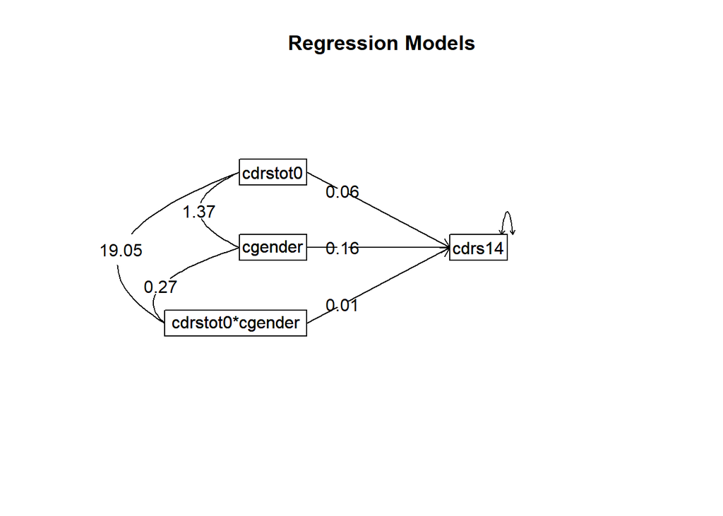

```r
plot(casiVera)
summary(casiVera)
```

```
##
## Multiple Regression from raw data
## setCor(y = cdrs14 ~ cdrstot0:cgender, data = abacab, std = FALSE)
##
## Multiple Regression from matrix input
##
## Beta weights
##                  cdrs14
## (Intercept)      1.9922
## cdrstot0         0.0625
## cgender          0.1630
## cdrstot0*cgender 0.0057
##
## Multiple R
## cdrs14
##   0.61
##
## Multiple R2
## cdrs14
##   0.37
##
## Cohen's set correlation R2
## [1] 0.37
##
## Squared Canonical Correlations
## NULL
```

```r
casiVera
```

```
## Call: setCor(y = cdrs14 ~ cdrstot0:cgender, data = abacab, std = FALSE)
##
## Multiple Regression from raw data
##
##  DV =  cdrs14
##                  slope   se     t        p lower.ci upper.ci  VIF Vy.x
## (Intercept)       1.99 0.04 50.06 4.1e-252     1.91     2.07 1.00 0.00
## cdrstot0          0.06 0.00 20.39  3.7e-75     0.06     0.07 1.09 0.36
## cgender           0.16 0.08  2.01  4.5e-02     0.00     0.32 1.05 0.01
## cdrstot0*cgender  0.01 0.01  0.96  3.4e-01    -0.01     0.02 1.05 0.00
##
## Residual Standard Error =  1.12  with  824  degrees of freedom
##
##  Multiple Regression
##           R   R2  Ruw R2uw Shrunken R2 SE of R2 overall F df1 df2        p
## cdrs14 0.61 0.37 0.47 0.22        0.37     0.03       162   3 824 1.25e-82
```

## Plotting interaction effects

To make a “presentation” version, what we want to do next to show the interaction is borrow Lia Follet’s ggplot2 code from her poster. :-)

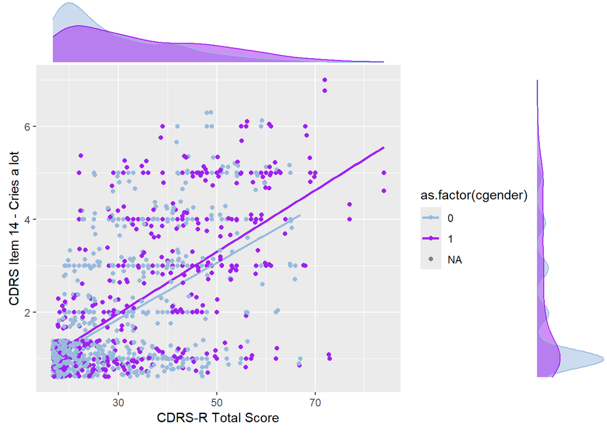

```r
#with gender as a moderator ggMarginal codes for the marginal histograms
DIFGraph <-ggplot(abacab, aes(x= cdrstot, y=cdrs14, colour=as.factor(cgender)))+geom_point() + scale_color_manual(values=c("#99BADD", "purple")) + geom_smooth(method="lm", se=FALSE) + xlab("CDRS-R Total Score")+ ylab("CDRS Item 14 - Cries a lot") +geom_jitter()+ scale_fill_discrete(name = "Sex", labels = c("Male", "Female", "Missing"))

ggMarginal(DIFGraph, groupColour=TRUE, groupFill = TRUE)
```

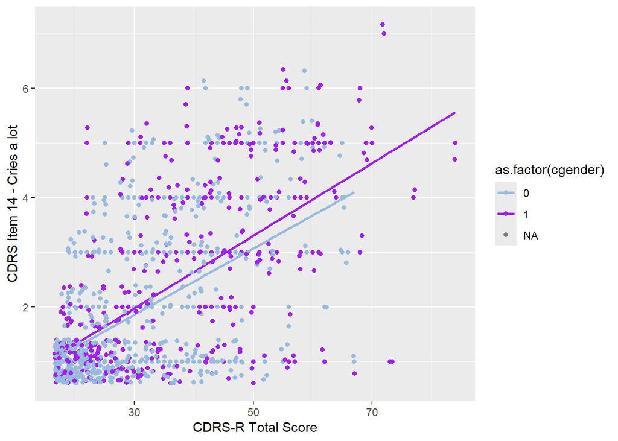

```r
DIFGraph
```

# Regression analyses using psych package

The command switches to mediate, and the mediator is in (parentheses) Documentation: https://cran.r-project.org/web/packages/psychTools/vignettes/mediation.pdf It can handle simple mediation, multiple mediators, serial mediation, and moderated mediation!

Revelle acknowledges that the Hayes macros have been bundled into the rProcess package, which would be another way of doing these.

## Mediation – silly example This is an example of modeling mediation. It’s a silly example because

the model does not actually make any sense conceptually – it flunks the “sniff test” just using common sense. But it’s showing two things: (a) how to use syntax to rearrange the variables to run a mediational model (b) why it is important to understand the variables and the model, because R will happily do stuff that makes no sense if you ask it!

In Revelle’s notation (author of psych package) c = “total effect” <– effect of predictor without including the mediator c’ = “direct effect” <– leftover direct effect that is not mediated.

```r
mediationex<-mediate(cmrsptot~(anyadhd)+agechild+bpvsall, data=modelvars, std=TRUE)
```

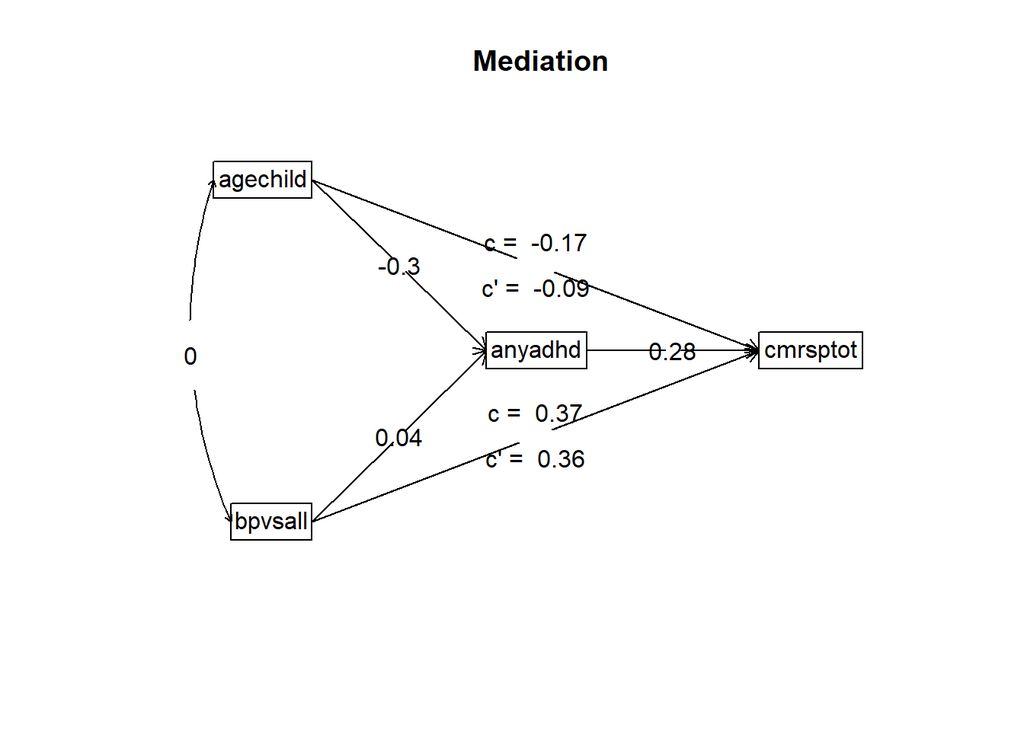

```r
plot(mediationex)
summary(mediationex)
```

[output not shown]

```r
mediationex
```

[output not shown]

#Now showing how to do stuff with t-test, ANOVA using rstatix.

https://www.rdocumentation.org/packages/rstatix/versions/0.7.0

## Still To Do: Block entry regression in R, with lm or psych

# Oneway ANOVA using rstatix

https://rdrr.io/cran/rstatix/f/README.md

```r
onewayResults<- aov((cmrsptot ~ as.factor(cgroup5)), data = modelvars)
onewayResults
```

```
## Call:
##    aov(formula = (cmrsptot ~ as.factor(cgroup5)), data = modelvars)
##
## Terms:
##                 as.factor(cgroup5) Residuals
## Sum of Squares               10768     50007
## Deg. of Freedom                  4       537
##
## Residual standard error: 9.65
## Estimated effects may be unbalanced
```

```r
anova_summary(onewayResults, effect.size="pes", detailed = TRUE)
```

|  | Effect | DFn | DFd | SSn | SSd | F | p | p<.05 | pes |
| --- | --- | --- | --- | --- | --- | --- | --- | --- | --- |
| 1 | as.factor(cgroup5) | 4 | 537 | 10768 | 50007 | 28.9 | 8.85e-22 | * | 0.177 |

# Mistakes to avoid

```r
doh<- aov((cmrsptot ~ cgroup5), data = modelvars)
doh
```

```
## Call:
##    aov(formula = (cmrsptot ~ cgroup5), data = modelvars)
##
## Terms:
##                 cgroup5 Residuals
## Sum of Squares     8492     52283
## Deg. of Freedom       1       540
##
## Residual standard error: 9.84
## Estimated effects may be unbalanced
```

```r
anova_summary(doh, effect.size="pes", detailed = TRUE)
```

|  | Effect | DFn | DFd | SSn | SSd | F | p | p<.05 | pes |
| --- | --- | --- | --- | --- | --- | --- | --- | --- | --- |
| 1 | cgroup5 | 1 | 540 | 8492 | 52283 | 87.7 | 2.04e-19 | * | 0.14 |

The “tell” is that there is only 1 df for the variable, when it should be (# of categories)-1

Here’s what it would look like in regression treating cgroup5 as (1) a continuous variable <– WRONG!!! (2) a factor <– correct!!!! (3) picking your comparison group <– fancy!!!!

```r
sadlyWrong2<- setCor(cmrsptot ~ cgroup5, data = modelvars)
```

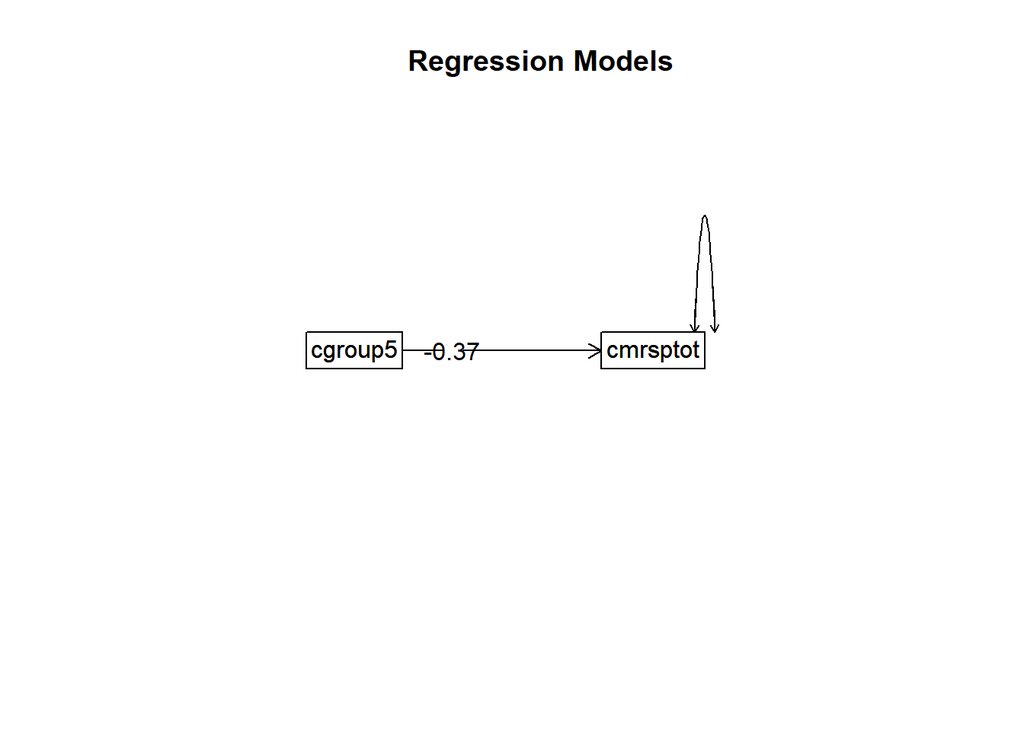

```r
sadlyWrong2
```

```
## Call: setCor(y = cmrsptot ~ cgroup5, data = modelvars)
##
## Multiple Regression from raw data
##
##  DV =  cmrsptot
##             slope   se     t     p lower.ci upper.ci VIF Vy.x
## (Intercept)  0.00 0.04  0.00 1e+00    -0.08     0.08   1 0.00
## cgroup5     -0.37 0.04 -9.37 2e-19    -0.45    -0.30   1 0.14
##
## Residual Standard Error =  0.93  with  540  degrees of freedom
##
##  Multiple Regression
##             R   R2   Ruw R2uw Shrunken R2 SE of R2 overall F df1 df2        p
## cmrsptot 0.37 0.14 -0.37 0.14        0.14     0.03      87.7   1 540 2.04e-19
```

```r
summary(sadlyWrong2, detailed = TRUE)
```

```
##
## Multiple Regression from raw data
## setCor(y = cmrsptot ~ cgroup5, data = modelvars)
##
## Multiple Regression from matrix input
##
## Beta weights
##             cmrsptot
## (Intercept)     0.00
## cgroup5        -0.37
##
## Multiple R
## cmrsptot
##     0.37
##
## Multiple R2
## cmrsptot
##     0.14
##
## Cohen's set correlation R2
## [1] 0.14
##
## Squared Canonical Correlations
## NULL
```

## a fix: declaring a categorical variable as a factor

```r
modelvars$cgroup5<- as.factor(modelvars$cgroup5)
rockOn<- lm(cmrsptot ~ cgroup5, data = modelvars)
rockOn
```

```
##
## Call:
## lm(formula = cmrsptot ~ cgroup5, data = modelvars)
##
## Coefficients:
## (Intercept)     cgroup52     cgroup53     cgroup54     cgroup55
##       24.44        -1.13       -10.02       -10.06       -18.18
```

```r
summary(rockOn, detailed = TRUE)
```

```
##
## Call:
## lm(formula = cmrsptot ~ cgroup5, data = modelvars)
##
## Residuals:
##    Min     1Q Median     3Q    Max
## -20.30  -6.42  -2.30   5.68  31.70
##
## Coefficients:
##             Estimate Std. Error t value Pr(>|t|)
## (Intercept)    24.44       2.41   10.13  < 2e-16 ***
## cgroup52       -1.13       2.62   -0.43     0.67
## cgroup53      -10.02       2.53   -3.96  8.6e-05 ***
## cgroup54      -10.06       2.49   -4.04  6.2e-05 ***
## cgroup55      -18.18       2.84   -6.41  3.2e-10 ***
## ---
## Signif. codes:  0 '***' 0.001 '**' 0.01 '*' 0.05 '.' 0.1 ' ' 1
##
## Residual standard error: 9.65 on 537 degrees of freedom
## Multiple R-squared:  0.177,  Adjusted R-squared:  0.171
## F-statistic: 28.9 on 4 and 537 DF,  p-value: <2e-16
```

## Changing the reference level for your dummy codes

R will automatically create dummy codes for your factor. It’s possible to pick which group gets assigned “0” for all the comparisons. This makes it the reference group, or the one that all other groups get compared against.

```r
fancy<- lm(cmrsptot ~ relevel(cgroup5, ref="5"), data = modelvars)
fancy
```

```
##
## Call:
## lm(formula = cmrsptot ~ relevel(cgroup5, ref = "5"), data = modelvars)
##
## Coefficients:
##                  (Intercept)  relevel(cgroup5, ref = "5")1
##                         6.26                         18.18
## relevel(cgroup5, ref = "5")2  relevel(cgroup5, ref = "5")3
##                        17.04                          8.16
## relevel(cgroup5, ref = "5")4
##                         8.11
```

```r
summary(fancy, detailed = TRUE)
```

```
##
## Call:
## lm(formula = cmrsptot ~ relevel(cgroup5, ref = "5"), data = modelvars)
##
## Residuals:
##    Min     1Q Median     3Q    Max
## -20.30  -6.42  -2.30   5.68  31.70
##
## Coefficients:
##                              Estimate Std. Error t value Pr(>|t|)
## (Intercept)                      6.26       1.49    4.21  3.1e-05 ***
## relevel(cgroup5, ref = "5")1    18.18       2.84    6.41  3.2e-10 ***
## relevel(cgroup5, ref = "5")2    17.04       1.81    9.43  < 2e-16 ***
## relevel(cgroup5, ref = "5")3     8.16       1.68    4.87  1.5e-06 ***
## relevel(cgroup5, ref = "5")4     8.11       1.62    5.02  7.0e-07 ***
## ---
## Signif. codes:  0 '***' 0.001 '**' 0.01 '*' 0.05 '.' 0.1 ' ' 1
##
## Residual standard error: 9.65 on 537 degrees of freedom
## Multiple R-squared:  0.177,  Adjusted R-squared:  0.171
## F-statistic: 28.9 on 4 and 537 DF,  p-value: <2e-16
```

## Boxplots (instead of bar charts)

…to figure out what the effect is If we decide that this is one of the main figures in the presentation, then we can give it some “TLC” in terms of axis labels, as well as general aesthetics. This is plenty helpful for a quick plot to get oriented, though!

# Group differences

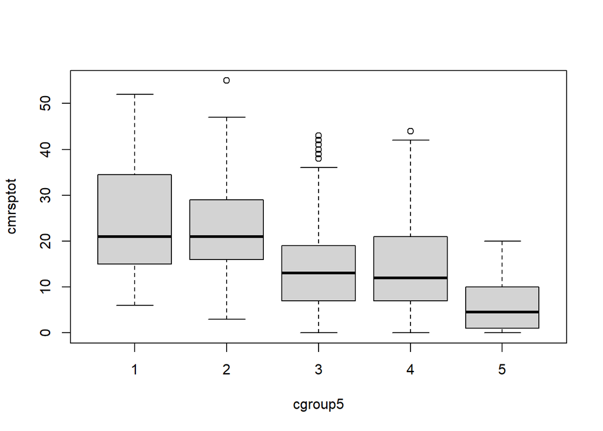

```r
boxplot(cmrsptot~cgroup5, data=modelvars)
```

Different post hoc tests compare the group means, while also trying to protect against “false positive” results (Type I errors).

Pairwise t-tests with a correction is one common approach.

rstatix can do all of these with a t-test: “holm” - Holm’s (1979) stepdown correction “hochberg” - Hochberg’s (1988) correction ” hommel” -Hommel’s (1988) correction “bonferroni” - Bonferroni correction –common, but it’s the worst for statistical power “BH”-Benjamini-Hochberg (1995) correction, also know as false discovery rate (FDR) “BY”- Benjamini-Yekutieli (2001) “fdr” - alias for Benjamini-Hochberg, above; commonly used in genetics and imaging work “none” - no error protection!

EY recommendations: FDR or Holm if you want to balance errors. Bonferroni if you want to be conservative or make it hard for groups to be significantly different.

```r
pairwise.t.test(modelvars$cmrsptot, modelvars$cgroup5,
                p.adjust.method = "BH") #Benjamini-Hochberg False Discovery Rate correction
```

```
##
##  Pairwise comparisons using t tests with pooled SD
##
## data:  modelvars$cmrsptot and modelvars$cgroup5
##
##   1     2      3     4
## 2 0.7   -      -     -
## 3 1e-04 4e-11  -     -
## 4 9e-05 2e-12  1.0   -
## 5 8e-10 <2e-16 2e-06 1e-06
##
## P value adjustment method: BH
```

```r
modelvars %>% games_howell_test(cmrsptot ~ cgroup5)
```

|  | .y. | group1 | group2 | estimate | conf.low | conf.high | p.adj | p.adj.signif |
| --- | --- | --- | --- | --- | --- | --- | --- | --- |
| 1 | cmrsptot | 1 | 2 | -1.1341 | -11.75 | 9.481 | 9.97e-01 | ns |
| 2 | cmrsptot | 1 | 3 | -10.0198 | -20.48 | 0.440 | 6.40e-02 | ns |
| 3 | cmrsptot | 1 | 4 | -10.0641 | -20.47 | 0.344 | 6.10e-02 | ns |
| 4 | cmrsptot | 1 | 5 | -18.1756 | -28.71 | -7.643 | 5.22e-04 | *** |
| 5 | cmrsptot | 2 | 3 | -8.8856 | -12.60 | -5.175 | 4.84e-09 | **** |
| 6 | cmrsptot | 2 | 4 | -8.9300 | -12.42 | -5.437 | 6.13e-10 | **** |
| 7 | cmrsptot | 2 | 5 | -17.0415 | -21.05 | -13.029 | 3.61e-14 | **** |
| 8 | cmrsptot | 3 | 4 | -0.0443 | -2.76 | 2.672 | 1.00e+00 | ns |
| 9 | cmrsptot | 3 | 5 | -8.1558 | -11.54 | -4.776 | 1.13e-08 | **** |
| 10 | cmrsptot | 4 | 5 | -8.1115 | -11.25 | -4.969 | 2.71e-09 | **** |

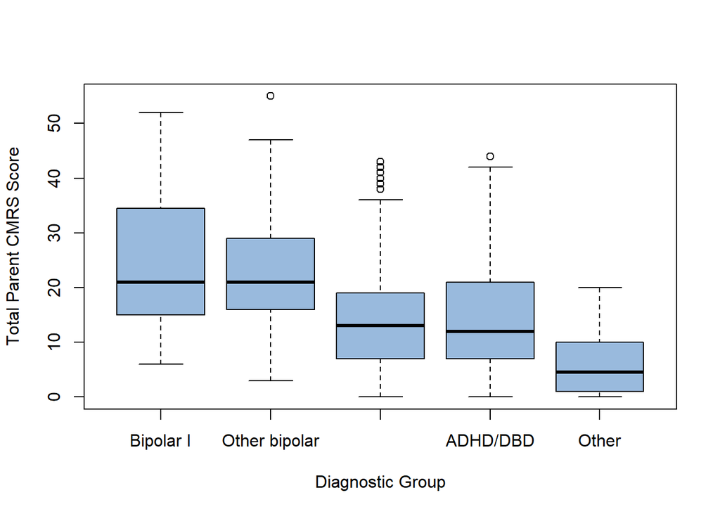

```r
boxplot(cmrsptot ~ cgroup5, data = modelvars,
        names = c("Bipolar I","Other bipolar","Unipolar Dep","ADHD/DBD","Other"), col="#99BADD", ylab = "Total Parent CMRS Score", xlab = "Diagnostic Group")
```

```r
# Grouped data
modelvars %>%
  group_by(anyadhd) %>%
  games_howell_test(cmrsptot ~ bpvsall)
```

|  | anyadhd | .y. | group1 | group2 | estimate | conf.low | conf.high | p.adj | p.adj.signif |
| --- | --- | --- | --- | --- | --- | --- | --- | --- | --- |
| 1 | 0 | cmrsptot | 0 | 1 | 9.92 | 6.24 | 13.6 | 2.78e-06 | **** |
| 2 | 1 | cmrsptot | 0 | 1 | 9.41 | 6.64 | 12.2 | 9.23e-10 | **** |

https://rpubs.com/pinkrpub/667245 for EDA visualization examples

# Chi Squared!

This page was helpful: http://www.sthda.com/english/wiki/chi-square-test-of-independence-in-r also https://statsandr.com/blog/chi-square-test-of-independence-in-r/#chi-square-test-of-independence-in-r

and Andy Fields has the helpful tip about requesting output as “SPSS” format. On p. 821 f. he recommends and walks through the gmodels package, which provides helpful output.

http://www.sthda.com/english/articles/32-r-graphics-essentials/129-visualizing-multivariate-categorical-data/

```r
library (vcd)
library (graphics)
library (gplots)
library (gmodels)
chisqResults<-chisq.test(table(modelvars$cgroup5, modelvars$anyadhd))
chisqResults #covers the basics, but not detailed
```

```
##
##  Pearson's Chi-squared test
##
## data:  table(modelvars$cgroup5, modelvars$anyadhd)
## X-squared = 118, df = 4, p-value <2e-16
```

```r
gmodels::CrossTable(modelvars$anyadhd, modelvars$cgroup5, chisq = TRUE, expected = TRUE,
                    sresid=TRUE, format = "SPSS")
```

```
##
##    Cell Contents
## |-------------------------|
## |                   Count |
## |         Expected Values |
## | Chi-square contribution |
## |             Row Percent |
## |          Column Percent |
## |           Total Percent |
## |            Std Residual |
## |-------------------------|
##
## Total Observations in Table:  542
##
##                   | modelvars$cgroup5
## modelvars$anyadhd |        1  |        2  |        3  |        4  |        5  | Row Total |
## ------------------|-----------|-----------|-----------|-----------|-----------|-----------|
##                 0 |        7  |       27  |       75  |       43  |       42  |      194  |
##                   |    5.727  |   31.856  |   56.554  |   84.830  |   15.033  |           |
##                   |    0.283  |    0.740  |    6.017  |   20.627  |   48.373  |           |
##                   |    3.608% |   13.918% |   38.660% |   22.165% |   21.649% |   35.793% |
##                   |   43.750% |   30.337% |   47.468% |   18.143% |  100.000% |           |
##                   |    1.292% |    4.982% |   13.838% |    7.934% |    7.749% |           |
##                   |    0.532  |   -0.860  |    2.453  |   -4.542  |    6.955  |           |
## ------------------|-----------|-----------|-----------|-----------|-----------|-----------|
##                 1 |        9  |       62  |       83  |      194  |        0  |      348  |
##                   |   10.273  |   57.144  |  101.446  |  152.170  |   26.967  |           |
##                   |    0.158  |    0.413  |    3.354  |   11.499  |   26.967  |           |
##                   |    2.586% |   17.816% |   23.851% |   55.747% |    0.000% |   64.207% |
##                   |   56.250% |   69.663% |   52.532% |   81.857% |    0.000% |           |
##                   |    1.661% |   11.439% |   15.314% |   35.793% |    0.000% |           |
##                   |   -0.397  |    0.642  |   -1.831  |    3.391  |   -5.193  |           |
## ------------------|-----------|-----------|-----------|-----------|-----------|-----------|
##      Column Total |       16  |       89  |      158  |      237  |       42  |      542  |
##                   |    2.952% |   16.421% |   29.151% |   43.727% |    7.749% |           |
## ------------------|-----------|-----------|-----------|-----------|-----------|-----------|
##
##
## Statistics for All Table Factors
##
##
## Pearson's Chi-squared test
## ------------------------------------------------------------
## Chi^2 =  118     d.f. =  4     p =  1.16e-24
##
##
##
##        Minimum expected frequency: 5.73
```

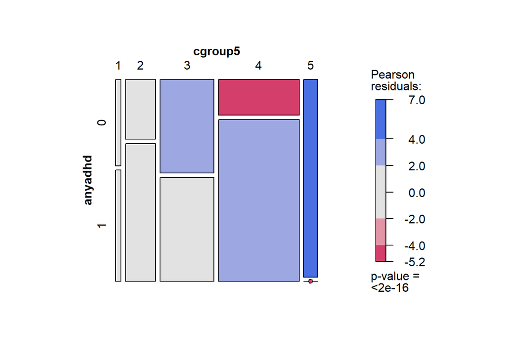

```r
vcd::mosaic(~cgroup5 + anyadhd, direction=c("v","h"), data=modelvars, shade=TRUE)
```

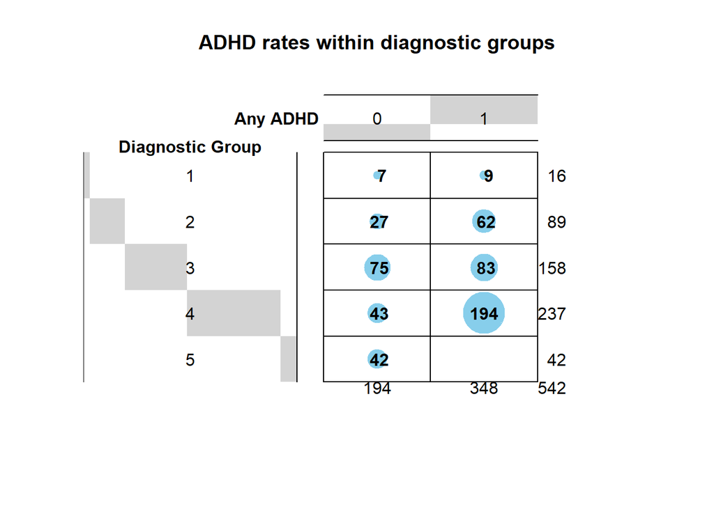

```r
tableInput<-table(modelvars$cgroup5, modelvars$anyadhd )
gplots::balloonplot(t(tableInput),
                      main="ADHD rates within diagnostic groups", xlab="Any ADHD", ylab="Diagnostic Group")
```

https://rdrr.io/cran/rstatix/man/games_howell_test.html

# Sufficient data for replication

There are two values in tension with research: wanting to have control of the data versus wanting to be transparent and replicable.

The ideas of sharing and reproducibility are core to Open Science. They also are newer ideas, so how to do it is evolving rapidly.

A “sweet spot” that tries to balance the two is to make a shareable version of the data that contains everything one would need to replicate… and not a single row or column more. That checks the boxes for reproducibility and transparency, and it lets you keep control of the rest of the data (and not “overshare”).

The easiest way to do it is to take the object that has the variables that made the “final cut” for this particular project, and then write out a copy of it (not the whole original dataset).

Then share that smaller file, but not the other one.

The simples way to do that is via the “write.csv” command. The default options spit out a comma separated value (= .csv) text file that can be read by anything that can read text, with the variable names (and nothing else) at the top. No missing value codes, no variable or value labels, none of the other goodies come through. But the variable names and the data are enough to check your results.

There are ways of adding back more information (there’s a write.sav command, and other ways of writing to SPSS, SAS, Excel, or other formats). Writing the sufficient data as a .sav would keep a lot more information, but it would also require the next person to use haven (or foreign, or expss… ) to read it (or fork over a lot of money to IBM, Microsoft, or whatever big tech firm is extracting the cash!).

A vanilla .csv is enough to get full credit for the class. A .sav file would be coming “full circle” –> we started with the data in an .sav file (curated by someone else), added value with a new question, research, analyses, and visualization, and the make it reproducible… and pay it forward with another labelled .sav file… completing “the Circle of Science”! (<– cue The Lion King soundtrack!)

```r
write.csv(modelvars, "YourNameSufficientData.csv")
```

#Advanced stuff

Extra bling: could get Cronbach’s alpha from own data!

Item names are cmrsp01 to cmrsp21.

```r
##need to input items
cmrsitems<-select(abacab, cmrsp01:cmrsp21) # make a smaller object with the variables we'll use for the examples

describe(cmrsitems) #note the different Ns due to missing data
```

|  | vars | n | mean | sd | median | trimmed | mad | min | max | range | skew | kurtosis | se |
| --- | --- | --- | --- | --- | --- | --- | --- | --- | --- | --- | --- | --- | --- |
| cmrsp01 | 1 | 544 | 0.724 | 0.833 | 1.0 | 0.5917 | 1.483 | 0 | 3 | 3 | 1.0850 | 0.6492 | 0.0357 |
| cmrsp02 | 2 | 543 | 1.141 | 0.995 | 1.0 | 1.0517 | 1.483 | 0 | 3 | 3 | 0.4687 | -0.8463 | 0.0427 |
| cmrsp03 | 3 | 545 | 0.983 | 1.058 | 1.0 | 0.8558 | 1.483 | 0 | 3 | 3 | 0.6930 | -0.8181 | 0.0453 |
| cmrsp04 | 4 | 544 | 0.256 | 0.644 | 0.0 | 0.0872 | 0.000 | 0 | 3 | 3 | 2.7965 | 7.5569 | 0.0276 |
| cmrsp05 | 5 | 544 | 0.498 | 0.830 | 0.0 | 0.3096 | 0.000 | 0 | 3 | 3 | 1.6942 | 2.0562 | 0.0356 |
| cmrsp06 | 6 | 542 | 1.100 | 1.115 | 1.0 | 1.0000 | 1.483 | 0 | 3 | 3 | 0.5702 | -1.0674 | 0.0479 |
| cmrsp07 | 7 | 544 | 1.290 | 1.098 | 1.0 | 1.2385 | 1.483 | 0 | 3 | 3 | 0.2930 | -1.2363 | 0.0471 |
| cmrsp08 | 8 | 543 | 0.761 | 0.956 | 0.0 | 0.6023 | 0.000 | 0 | 3 | 3 | 1.0362 | -0.0396 | 0.0410 |
| cmrsp09 | 9 | 544 | 0.792 | 0.955 | 0.5 | 0.6399 | 0.741 | 0 | 3 | 3 | 0.9798 | -0.1221 | 0.0410 |
| cmrsp10 | 10 | 547 | 0.792 | 0.984 | 0.0 | 0.6241 | 0.000 | 0 | 3 | 3 | 1.0129 | -0.1390 | 0.0421 |

[output cut: 11 more lines]

```r
cmrsitemsShrunk<-na.omit(cmrsitems) #listwise delete for complete items
describe(cmrsitemsShrunk)
```

|  | vars | n | mean | sd | median | trimmed | mad | min | max | range | skew | kurtosis | se |
| --- | --- | --- | --- | --- | --- | --- | --- | --- | --- | --- | --- | --- | --- |
| cmrsp01 | 1 | 522 | 0.722 | 0.834 | 1 | 0.5861 | 1.48 | 0 | 3 | 3 | 1.1096 | 0.7224 | 0.0365 |
| cmrsp02 | 2 | 522 | 1.148 | 0.996 | 1 | 1.0610 | 1.48 | 0 | 3 | 3 | 0.4577 | -0.8592 | 0.0436 |
| cmrsp03 | 3 | 522 | 0.975 | 1.061 | 1 | 0.8445 | 1.48 | 0 | 3 | 3 | 0.7228 | -0.7795 | 0.0464 |
| cmrsp04 | 4 | 522 | 0.255 | 0.640 | 0 | 0.0885 | 0.00 | 0 | 3 | 3 | 2.7934 | 7.5909 | 0.0280 |
| cmrsp05 | 5 | 522 | 0.490 | 0.827 | 0 | 0.2990 | 0.00 | 0 | 3 | 3 | 1.7264 | 2.1771 | 0.0362 |
| cmrsp06 | 6 | 522 | 1.082 | 1.108 | 1 | 0.9785 | 1.48 | 0 | 3 | 3 | 0.5983 | -1.0200 | 0.0485 |
| cmrsp07 | 7 | 522 | 1.280 | 1.097 | 1 | 1.2249 | 1.48 | 0 | 3 | 3 | 0.3109 | -1.2250 | 0.0480 |
| cmrsp08 | 8 | 522 | 0.753 | 0.951 | 0 | 0.5933 | 0.00 | 0 | 3 | 3 | 1.0564 | 0.0202 | 0.0416 |
| cmrsp09 | 9 | 522 | 0.791 | 0.946 | 1 | 0.6411 | 1.48 | 0 | 3 | 3 | 0.9817 | -0.0807 | 0.0414 |
| cmrsp10 | 10 | 522 | 0.785 | 0.980 | 0 | 0.6172 | 0.00 | 0 | 3 | 3 | 1.0250 | -0.1033 | 0.0429 |

[output cut: 11 more lines]

```r
headTail(cmrsitemsShrunk)
```

| cmrsp01 | cmrsp02 | cmrsp03 | cmrsp04 | cmrsp05 | cmrsp06 | cmrsp07 | cmrsp08 | cmrsp09 | cmrsp10 | cmrsp11 | cmrsp12 | cmrsp13 | cmrsp14 | cmrsp15 | cmrsp16 | cmrsp17 | cmrsp18 | cmrsp19 | cmrsp20 | cmrsp21 |
| --- | --- | --- | --- | --- | --- | --- | --- | --- | --- | --- | --- | --- | --- | --- | --- | --- | --- | --- | --- | --- |
| 1 | 1 | 1 | 1 | 1 | 1 | 1 | 1 | 1 | 1 | 1 | 1 | 1 | 1 | 1 | 1 | 1 | 1 | 1 | 0 | 1 |
| 1 | 0 | 1 | 0 | 0 | 0 | 0 | 0 | 0 | 0 | 1 | 1 | 0 | 0 | 0 | 0 | 0 | 1 | 0 | 0 | 0 |
| 1 | 2 | 0 | 0 | 1 | 3 | 3 | 1 | 1 | 2 | 3 | 0 | 0 | 1 | 1 | 3 | 0 | 3 | 0 | 0 | 0 |
| 3 | 3 | 3 | 0 | 2 | 3 | 3 | 3 | 3 | 3 | 3 | 3 | 1 | 2 | 0 | 3 | 2 | 3 | 3 | 3 | 3 |
| ... | ... | ... | ... | ... | ... | ... | ... | ... | ... | ... | ... | ... | ... | ... | ... | ... | ... | ... | ... | ... |
| 0 | 0 | 0 | 0 | 1 | 3 | 2 | 1 | 1 | 0 | 2 | 0 | 0 | 0 | 0 | 0 | 0 | 1 | 0 | 1 | 0 |
| 1 | 2 | 0 | 0 | 0 | 1 | 0 | 0 | 0 | 1 | 1 | 1 | 1 | 0 | 0 | 1 | 0 | 1 | 1 | 1 | 1 |
| 0 | 0 | 0 | 0 | 0 | 0 | 2 | 1 | 1 | 1 | 1 | 0 | 0 | 0 | 0 | 1 | 1 | 1 | 0 | 0 | 0 |
| 0 | 3 | 0 | 0 | 0 | 0 | 3 | 0 | 3 | 0 | 3 | 0 | 0 | 0 | 0 | 3 | 0 | 3 | 0 | 0 | 0 |

```r
##need to input items
bdsitems<-select(ku2017, bds01, bds02, bds04, bds05, bds06, bds08, bds10) # make a smaller object with the variables we'll use for the examples


describe(bdsitems) #note the different Ns due to missing data
```

|  | vars | n | mean | sd | median | trimmed | mad | min | max | range | skew | kurtosis | se |
| --- | --- | --- | --- | --- | --- | --- | --- | --- | --- | --- | --- | --- | --- |
| bds01 | 1 | 689 | 1.22 | 0.413 | 1 | 1.15 | 0 | 1 | 2 | 1 | 1.365 | -0.137 | 0.0157 |
| bds02 | 2 | 539 | 1.35 | 0.478 | 1 | 1.31 | 0 | 1 | 2 | 1 | 0.624 | -1.613 | 0.0206 |
| bds04 | 3 | 350 | 1.34 | 0.473 | 1 | 1.30 | 0 | 1 | 2 | 1 | 0.686 | -1.534 | 0.0253 |
| bds05 | 4 | 350 | 1.39 | 0.489 | 1 | 1.36 | 0 | 1 | 2 | 1 | 0.443 | -1.809 | 0.0261 |
| bds06 | 5 | 350 | 1.57 | 0.495 | 2 | 1.59 | 0 | 1 | 2 | 1 | -0.299 | -1.916 | 0.0265 |
| bds08 | 6 | 350 | 1.77 | 0.424 | 2 | 1.83 | 0 | 1 | 2 | 1 | -1.249 | -0.440 | 0.0227 |
| bds10 | 7 | 350 | 1.34 | 0.475 | 1 | 1.30 | 0 | 1 | 2 | 1 | 0.659 | -1.570 | 0.0254 |

```r
bdsitemsShrunk<-na.omit(bdsitems) #listwise delete for complete items
describe(bdsitemsShrunk)
```

|  | vars | n | mean | sd | median | trimmed | mad | min | max | range | skew | kurtosis | se |
| --- | --- | --- | --- | --- | --- | --- | --- | --- | --- | --- | --- | --- | --- |
| bds01 | 1 | 350 | 1.00 | 0.000 | 1 | 1.00 | 0 | 1 | 1 | 0 | NaN | NaN | 0.0000 |
| bds02 | 2 | 350 | 1.00 | 0.000 | 1 | 1.00 | 0 | 1 | 1 | 0 | NaN | NaN | 0.0000 |
| bds04 | 3 | 350 | 1.34 | 0.473 | 1 | 1.30 | 0 | 1 | 2 | 1 | 0.686 | -1.53 | 0.0253 |
| bds05 | 4 | 350 | 1.39 | 0.489 | 1 | 1.36 | 0 | 1 | 2 | 1 | 0.443 | -1.81 | 0.0261 |
| bds06 | 5 | 350 | 1.57 | 0.495 | 2 | 1.59 | 0 | 1 | 2 | 1 | -0.299 | -1.92 | 0.0265 |
| bds08 | 6 | 350 | 1.77 | 0.424 | 2 | 1.83 | 0 | 1 | 2 | 1 | -1.249 | -0.44 | 0.0227 |
| bds10 | 7 | 350 | 1.34 | 0.475 | 1 | 1.30 | 0 | 1 | 2 | 1 | 0.659 | -1.57 | 0.0254 |

```r
headTail(bdsitemsShrunk)
```

| bds01 | bds02 | bds04 | bds05 | bds06 | bds08 | bds10 |
| --- | --- | --- | --- | --- | --- | --- |
| 1 | 1 | 1 | 1 | 1 | 1 | 1 |
| 1 | 1 | 1 | 2 | 2 | 2 | 2 |
| 1 | 1 | 1 | 2 | 1 | 2 | 2 |
| 1 | 1 | 1 | 2 | 2 | 2 | 1 |
| ... | ... | ... | ... | ... | ... | ... |
| 1 | 1 | 2 | 2 | 2 | 2 | 1 |
| 1 | 1 | 2 | 2 | 2 | 2 | 1 |
| 1 | 1 | 1 | 2 | 2 | 2 | 2 |
| 1 | 1 | 1 | 1 | 1 | 2 | 2 |

# Reliability

## Alpha

Cronbach’s alpha, the most widely reported form of internal consistency reliability, is in the psych package

```r
psych::alpha(bdsitemsShrunk)
```

```
##
## Reliability analysis
## Call: psych::alpha(x = bdsitemsShrunk)
##
##   raw_alpha std.alpha G6(smc) average_r S/N   ase mean   sd median_r
##       0.66      0.66    0.65      0.28   2 0.028  1.3 0.22     0.27
##
##     95% confidence boundaries
##          lower alpha upper
## Feldt     0.60  0.66  0.72
## Duhachek  0.61  0.66  0.72
##
##  Reliability if an item is dropped:
##       raw_alpha std.alpha G6(smc) average_r S/N alpha se  var.r med.r
## bds04      0.69      0.69    0.65      0.36 2.2    0.027 0.0158  0.33
## bds05      0.55      0.56    0.53      0.24 1.3    0.039 0.0268  0.21
## bds06      0.56      0.56    0.50      0.24 1.3    0.038 0.0077  0.24
## bds08      0.60      0.60    0.55      0.27 1.5    0.035 0.0137  0.27
## bds10      0.64      0.64    0.61      0.30 1.8    0.032 0.0328  0.31
##
##  Item statistics
##         n raw.r std.r r.cor r.drop mean   sd
## bds04 350  0.52  0.52  0.30   0.24  1.3 0.47
## bds05 350  0.74  0.73  0.64   0.53  1.4 0.49
## bds06 350  0.73  0.73  0.67   0.51  1.6 0.50
## bds08 350  0.66  0.67  0.58   0.45  1.8 0.42
## bds10 350  0.62  0.61  0.44   0.36  1.3 0.48
##
## Non missing response frequency for each item
##          1    2 miss
## bds04 0.66 0.34    0
## bds05 0.61 0.39    0
## bds06 0.43 0.57    0
## bds08 0.23 0.77    0
## bds10 0.66 0.34    0
```

## Omega – an alternative reliability measure

Omega also is in the psych package.

```r
psych::omega(cmrsitemsShrunk, nfactors=2)
```

```
##
## Three factors are required for identification -- general factor loadings set to be equal.
## Proceed with caution.
## Think about redoing the analysis with alternative values of the 'option' setting.
```

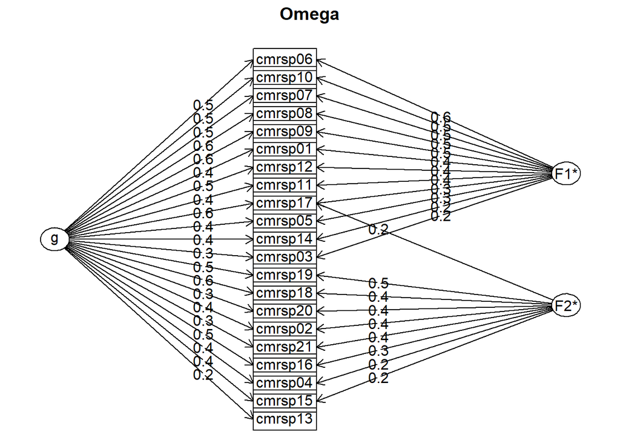

```
## Omega
## Call: omegah(m = m, nfactors = nfactors, fm = fm, key = key, flip = flip,
##     digits = digits, title = title, sl = sl, labels = labels,
##     plot = plot, n.obs = n.obs, rotate = rotate, Phi = Phi, option = option,
##     covar = covar)
## Alpha:                 0.89
## G.6:                   0.91
## Omega Hierarchical:    0.62
## Omega H asymptotic:    0.68
## Omega Total            0.9
##
## Schmid Leiman Factor loadings greater than  0.2
##            g   F1*   F2*    h2   h2   u2   p2  com
## cmrsp01 0.43  0.38        0.33 0.33 0.67 0.56 1.98
## cmrsp02 0.44        0.40  0.36 0.36 0.64 0.55 1.98
## cmrsp03 0.29  0.21             0.14 0.86 0.63 1.95
## cmrsp04 0.36        0.23  0.20 0.20 0.80 0.67 1.93
## cmrsp05 0.40  0.25        0.24 0.24 0.76 0.66 1.93
## cmrsp06 0.54  0.59        0.65 0.65 0.35 0.44 2.02
## cmrsp07 0.54  0.52        0.56 0.56 0.44 0.52 2.00
## cmrsp08 0.57  0.49        0.57 0.57 0.43 0.57 1.98
## cmrsp09 0.57  0.49        0.56 0.56 0.44 0.58 1.98
## cmrsp10 0.52  0.54        0.56 0.56 0.44 0.48 2.01
## cmrsp11 0.41  0.35        0.29 0.29 0.71 0.57 1.98
## cmrsp12 0.51  0.37        0.41 0.41 0.59 0.63 1.95
## cmrsp13 0.20                   0.07 0.93 0.57 1.98
## cmrsp14 0.36  0.22        0.20 0.20 0.80 0.67 1.93
## cmrsp15 0.40        0.21  0.23 0.23 0.77 0.68 1.92
## cmrsp16 0.52        0.31  0.40 0.40 0.60 0.67 1.93
## cmrsp17 0.55  0.28  0.25  0.45 0.45 0.55 0.69 1.92
## cmrsp18 0.55        0.43  0.50 0.50 0.50 0.61 1.96
## cmrsp19 0.46        0.47  0.43 0.43 0.57 0.49 2.01
## cmrsp20 0.35        0.40  0.29 0.29 0.71 0.42 2.03
## cmrsp21 0.30        0.38  0.24 0.24 0.76 0.37 2.04
##
## With Sums of squares  of:
##   g F1* F2*  h2
## 4.3 2.1 1.2 3.3
##
## general/max  1.3   max/min =   2.74
```

[output cut: 15 more lines]

```
##
## RMSEA index =  0.123  and the 10 % confidence intervals are  0.117 0.128
## BIC =  493
##
## Measures of factor score adequacy
##                                                  g  F1*   F2*
## Correlation of scores with factors            0.79 0.72  0.68
## Multiple R square of scores with factors      0.63 0.52  0.46
## Minimum correlation of factor score estimates 0.25 0.05 -0.07
##
##  Total, General and Subset omega for each subset
##                                                  g  F1*  F2*
## Omega total for total scores and subscales    0.90 0.88 0.77
## Omega general for total scores and subscales  0.62 0.52 0.45
## Omega group for total scores and subscales    0.22 0.35 0.32
```

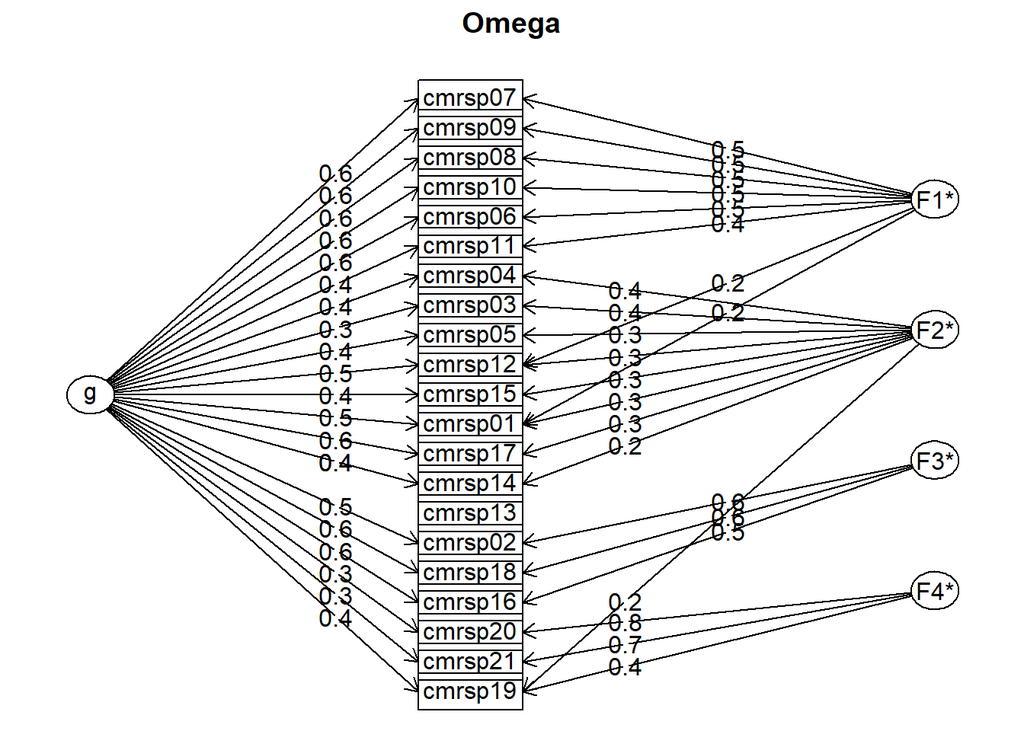

```
## Omega
## Call: omegah(m = m, nfactors = nfactors, fm = fm, key = key, flip = flip,
##     digits = digits, title = title, sl = sl, labels = labels,
##     plot = plot, n.obs = n.obs, rotate = rotate, Phi = Phi, option = option,
##     covar = covar)
## Alpha:                 0.89
## G.6:                   0.91
## Omega Hierarchical:    0.68
## Omega H asymptotic:    0.73
## Omega Total            0.92
##
## Schmid Leiman Factor loadings greater than  0.2
##            g   F1*   F2*   F3*   F4*    h2   h2   u2   p2  com
## cmrsp01 0.47  0.24  0.27              0.37 0.37 0.63 0.61 2.20
## cmrsp02 0.46              0.60        0.59 0.59 0.41 0.37 1.90
## cmrsp03 0.32        0.37              0.25 0.25 0.75 0.42 2.04
## cmrsp04 0.38        0.45              0.35 0.35 0.65 0.42 2.12
## cmrsp05 0.43        0.32              0.31 0.31 0.69 0.60 2.07
## cmrsp06 0.59  0.49                    0.62 0.62 0.38 0.56 2.11
## cmrsp07 0.58  0.52                    0.62 0.62 0.38 0.55 2.01
## cmrsp08 0.61  0.51                    0.64 0.64 0.36 0.58 2.01
## cmrsp09 0.61  0.51                    0.63 0.63 0.37 0.58 2.01
## cmrsp10 0.57  0.50                    0.58 0.58 0.42 0.55 2.00
## cmrsp11 0.44  0.36                    0.33 0.33 0.67 0.58 2.10
## cmrsp12 0.55  0.23  0.30              0.45 0.45 0.55 0.66 1.97
## cmrsp13 0.20                               0.07 0.93 0.55 2.67
## cmrsp14 0.38        0.20              0.22 0.22 0.78 0.66 2.06
## cmrsp15 0.41        0.29              0.27 0.27 0.73 0.62 2.06
## cmrsp16 0.55              0.55        0.61 0.61 0.39 0.50 2.09
## cmrsp17 0.58        0.26              0.46 0.46 0.54 0.72 1.83
## cmrsp18 0.57              0.59        0.68 0.68 0.32 0.48 2.03
## cmrsp19 0.44        0.23        0.36  0.41 0.41 0.59 0.47 2.95
## cmrsp20 0.32                    0.76  0.67 0.67 0.33 0.15 1.37
## cmrsp21 0.27                    0.73  0.60 0.60 0.40 0.12 1.29
##
## With Sums of squares  of:
##   g F1* F2* F3* F4*  h2
## 4.8 1.6 0.9 1.1 1.3 5.2
##
## general/max  0.93   max/min =   5.71
```

[output cut: 15 more lines]

```
##
## RMSEA index =  0.119  and the 10 % confidence intervals are  0.114 0.125
## BIC =  407
##
## Measures of factor score adequacy
##                                                  g  F1*   F2*  F3*  F4*
## Correlation of scores with factors            0.83 0.72  0.70 0.77 0.86
## Multiple R square of scores with factors      0.69 0.52  0.49 0.59 0.75
## Minimum correlation of factor score estimates 0.38 0.05 -0.03 0.19 0.49
##
##  Total, General and Subset omega for each subset
##                                                  g  F1*  F2*  F3*  F4*
## Omega total for total scores and subscales    0.92 0.89 0.73 0.83 0.76
## Omega general for total scores and subscales  0.68 0.51 0.49 0.38 0.18
## Omega group for total scores and subscales    0.15 0.37 0.24 0.45 0.58
```

```r
psych::omega(cmrsitemsShrunk, nfactors=4)
```

## Exploratory factor analysis

Factor analysis is an “easter egg” – not something required for a poster in 525.

```r
# Maximum Likelihood Factor Analysis
# entering raw data and extracting 2 factors,
# with varimax rotation

cmrsmlfit <- factanal(cmrsitemsShrunk, 2, rotation="promax")
print(cmrsmlfit, digits=2, cutoff=.3, sort=TRUE)
```

```
##
## Call:
## factanal(x = cmrsitemsShrunk, factors = 2, rotation = "promax")
##
## Uniquenesses:
## cmrsp01 cmrsp02 cmrsp03 cmrsp04 cmrsp05 cmrsp06 cmrsp07 cmrsp08 cmrsp09 cmrsp10
##    0.69    0.43    0.88    0.84    0.77    0.40    0.42    0.38    0.40    0.42
## cmrsp11 cmrsp12 cmrsp13 cmrsp14 cmrsp15 cmrsp16 cmrsp17 cmrsp18 cmrsp19 cmrsp20
##    0.70    0.61    0.95    0.81    0.80    0.46    0.58    0.33    0.72    0.88
## cmrsp21
##    0.90
##
## Loadings:
##         Factor1 Factor2
## cmrsp01  0.54
## cmrsp06  0.87
## cmrsp07  0.81
## cmrsp08  0.84
## cmrsp09  0.80
## cmrsp10  0.88
## cmrsp11  0.52
## cmrsp12  0.53
## cmrsp02 -0.30    0.93
## cmrsp16          0.75
## cmrsp18          0.91
## cmrsp19          0.52
## cmrsp03
## cmrsp04
## cmrsp05  0.32
## cmrsp13
## cmrsp14  0.39
## cmrsp15
## cmrsp17  0.35    0.35
## cmrsp20
## cmrsp21
##
##                Factor1 Factor2
## SS loadings       5.07    3.12
## Proportion Var    0.24    0.15
## Cumulative Var    0.24    0.39
##
## Factor Correlations:
##         Factor1 Factor2
## Factor1    1.00   -0.71
## Factor2   -0.71    1.00
##
## Test of the hypothesis that 2 factors are sufficient.
## The chi square statistic is 950 on 169 degrees of freedom.
## The p-value is 4.96e-109
```

[figure not shown]

```r
plot.new()
load <- cmrsmlfit$loadings[,1:2]

text(load,labels=names(cmrsitems),cex=.7) # add variable names
```

```r
# Principal Axis Factor Analysis



#library(psych)
cmrsefa <- factor.pa(cmrsitemsShrunk, nfactors=5, rotate="promax")
cmrsefa # print results
```

```
## Factor Analysis using method =  pa
## Call: factor.pa(r = cmrsitemsShrunk, nfactors = 5, rotate = "promax")
## Unstandardized loadings (pattern matrix) based upon covariance matrix
##           PA1   PA3   PA4   PA2   PA5   h2   u2   H2   U2
## cmrsp01  0.19 -0.01  0.65  0.04 -0.19 0.48 0.52 0.48 0.52
## cmrsp02 -0.11 -0.81 -0.05 -0.04  0.06 0.58 0.42 0.58 0.42
## cmrsp03 -0.11  0.06  0.66  0.02 -0.03 0.32 0.68 0.32 0.68
## cmrsp04 -0.19  0.04  0.43  0.04  0.36 0.34 0.66 0.34 0.66
## cmrsp05  0.04 -0.05  0.39 -0.06  0.17 0.31 0.69 0.31 0.69
## cmrsp06  0.63  0.04  0.37 -0.04 -0.12 0.65 0.35 0.65 0.35
## cmrsp07  0.74 -0.08  0.08  0.03 -0.12 0.62 0.38 0.62 0.38
## cmrsp08  0.75  0.05 -0.03  0.06  0.14 0.65 0.35 0.65 0.35
## cmrsp09  0.79 -0.01 -0.13  0.02  0.17 0.67 0.33 0.67 0.33
## cmrsp10  0.71  0.09  0.09 -0.01  0.07 0.58 0.42 0.58 0.42
## cmrsp11  0.53 -0.13 -0.05 -0.02  0.01 0.33 0.67 0.33 0.67
## cmrsp12  0.24  0.01  0.33 -0.05  0.24 0.45 0.55 0.45 0.55
## cmrsp13 -0.01  0.01 -0.19 -0.09  0.57 0.21 0.79 0.21 0.79
## cmrsp14  0.21  0.13 -0.01 -0.06  0.52 0.31 0.69 0.31 0.69
## cmrsp15  0.02 -0.01  0.17 -0.02  0.42 0.30 0.70 0.30 0.70
## cmrsp16  0.09 -0.75  0.03 -0.10 -0.02 0.61 0.39 0.61 0.39
## cmrsp17  0.15 -0.20  0.31  0.03  0.16 0.46 0.54 0.46 0.54
## cmrsp18  0.02 -0.82  0.01  0.06 -0.04 0.70 0.30 0.70 0.30
## cmrsp19 -0.10 -0.17  0.05  0.26  0.41 0.43 0.57 0.43 0.57
## cmrsp20  0.01  0.05  0.08  0.87 -0.01 0.76 0.24 0.76 0.24
## cmrsp21  0.07 -0.01 -0.09  0.75  0.01 0.58 0.42 0.58 0.42
##
##                        PA1  PA3  PA4  PA2  PA5
## SS loadings           3.45 2.03 1.92 1.45 1.47
## Proportion Var        0.16 0.10 0.09 0.07 0.07
## Cumulative Var        0.16 0.26 0.35 0.42 0.49
## Proportion Explained  0.33 0.20 0.19 0.14 0.14
## Cumulative Proportion 0.33 0.53 0.72 0.86 1.00
##
##  Standardized loadings (pattern matrix)
##         item   PA1   PA3   PA4   PA2   PA5   h2   u2
## cmrsp01    1  0.19 -0.01  0.65  0.04 -0.19 0.48 0.52
## cmrsp02    2 -0.11 -0.81 -0.05 -0.04  0.06 0.58 0.42
## cmrsp03    3 -0.11  0.06  0.66  0.02 -0.03 0.32 0.68
## cmrsp04    4 -0.19  0.04  0.43  0.04  0.36 0.34 0.66
## cmrsp05    5  0.04 -0.05  0.39 -0.06  0.17 0.31 0.69
```

[output cut: 37 more lines]

```
## The root mean square of the residuals (RMSR) is  0.02
## The df corrected root mean square of the residuals is  0.03
##
## The harmonic n.obs is  522 with the empirical chi square  134  with prob <  0.1
## The total n.obs was  522  with Likelihood Chi Square =  288  with prob <  8.2e-17
##
## Tucker Lewis Index of factoring reliability =  0.923
## RMSEA index =  0.054  and the 90 % confidence intervals are  0.046 0.062
## BIC =  -432
## Fit based upon off diagonal values = 0.99
## Measures of factor score adequacy
##                                                    PA1  PA3  PA4  PA2  PA5
## Correlation of (regression) scores with factors   0.95 0.93 0.89 0.91 0.86
## Multiple R square of scores with factors          0.90 0.86 0.79 0.83 0.74
## Minimum correlation of possible factor scores     0.80 0.72 0.58 0.66 0.48
```

```r
library (nFactors)
```

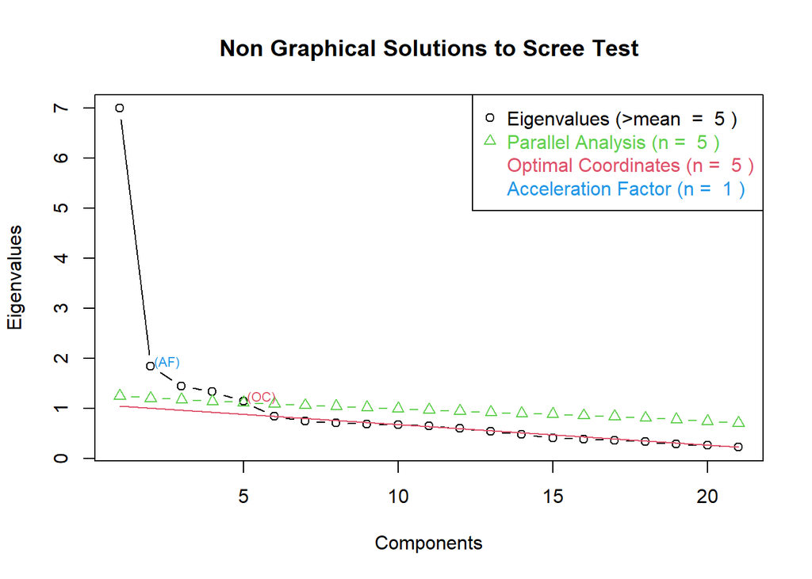

```r
ev <- eigen(cor(cmrsitemsShrunk)) # get eigenvalues
ap <- nFactors::parallel(subject=nrow(cmrsitems),var=ncol(cmrsitems),
                         rep=100,cent=.05)
nS <- nScree(x=ev$values, aparallel=ap$eigen$qevpea)
plotnScree(nS)
```

## Item Response Theory (IRT)

```r
library(mirt)
modelcmrs.grm<-'cmrs = 1-21'
resultscmrs.grm<-mirt(data=cmrsitemsShrunk,
                      model=modelcmrs.grm, itemtype="graded", SE=TRUE, verbose=FALSE)
coefcmrs.grm<-coef(resultscmrs.grm, IRTpars=TRUE, simplify=TRUE, na.rm=TRUE)
itemscmrs.grm<-as.data.frame(coefcmrs.grm$items)
print(itemscmrs.grm)
```

```
##             a        b1    b2   b3
## cmrsp01 1.409 -1.17e-01 1.658 2.57
## cmrsp02 0.992 -9.64e-01 0.842 2.28
## cmrsp03 0.757 -3.27e-01 1.422 2.75
## cmrsp04 1.186  1.66e+00 2.800 3.63
## cmrsp05 1.222  7.45e-01 2.055 2.85
## cmrsp06 2.342 -2.85e-01 0.610 1.16
## cmrsp07 2.299 -5.94e-01 0.391 1.09
## cmrsp08 2.845  9.79e-02 0.941 1.62
## cmrsp09 2.781 -2.85e-05 0.948 1.65
## cmrsp10 2.337  7.99e-02 0.995 1.65
## cmrsp11 1.249 -1.27e+00 0.127 1.31
## cmrsp12 1.839  2.44e-02 1.313 2.25
## cmrsp13 0.643  2.91e+00 4.788 5.65
## cmrsp14 1.298  1.29e+00 2.597 3.92
## cmrsp15 1.107  7.36e-01 2.324 3.72
## cmrsp16 1.443 -5.78e-01 0.722 1.59
## cmrsp17 1.769 -2.73e-01 1.015 2.01
## cmrsp18 1.539 -5.47e-01 0.635 1.39
## cmrsp19 1.162  9.48e-01 2.461 3.68
## cmrsp20 0.838  2.08e+00 3.839 4.95
## cmrsp21 0.834  2.34e+00 4.278 5.37
```

```r
##write_csv(itemscmrs.grm, "itemscmrs.csv")
```

#Sandbox

This is where stuff that is not finished goes. To get R to do a diagram for us, we can use the rockchalk package. Unfortunately, rockchalk doesn’t read the results from setCorr, so we have to switch to lm.

casiVera2<-lm(cdrs14~cdrstot0*cgender, data=abacab) summary(casiVera2) sketch<-plotSlopes(casiVera2, plotx=“cdrstot0”, xlab=“Total CDRS-R Score (0=minimum)”, interval=“confidence”, opacity=80, col=“purple”, ylim=c(1,7), legendArgs=list(x=“topright”)) sketch

Code from EGC:

Reg <- lm(hopelec~CPSStot+fadtotalpomp, data=RES2) summary(Reg) RegModel <- lm(hopelec~CPSStot*fadtotalpomp, data=RES2) summary(RegModel)

m3ps <- plotSlopes(RegModel, modx = “fadtotalpomp”, plotx = “CPSStot”, n=3, modxVals=“std.dev”) m3psts <- testSlopes(m3ps) round(m3psts$hypotests,4)

basicStats(RES) #Get N, min & max (compare to source docs), skew & kurtosis pairs.panels(RES) #Look at histograms, scatterplots, LOESS smoother #ggpairs(RES) pairs.panels(RES) #regression findings plot_summs(RegModel, robust = TRUE, plot.distributions = TRUE, rescale.distributions = TRUE) export_summs(RegModel, model.names = c(“Global Family Functioning’s Impact on the Relationship of Child Post-Traumatic Symptoms on Child Hopelessness and Helplessness Outlook”), robust = TRUE, VIF = TRUE, error_format = “({statistic}, p = {p.value})[CI 95% {conf.low}, {conf.high}]”, model.fit = TRUE, to.file = “xlsx”, file.name = “finalmodels1.xlsx”)

The “codebook” package generates a huge amount of information about a data file. The defaults on this are extensive and take a LONG time to run. Prohibitively large for most uses. We could explore how to turn off a bunch of the features to make it more manageable.

```r
#library(codebook)
#codebook(bfi)
```

## Various ways of getting descriptives and checking assumptions

rstatix::get_summary_stats(): Compute summary statistics for one or multiple numeric variables. Can handle grouped data.

rstatix::freq_table(): Compute frequency table of categorical variables.

rstatix::get_mode(): Compute the mode of a vector, that is the most frequent values.

rstatix::identify_outliers(): Detect univariate outliers using boxplot methods.

rstatix::mahalanobis_distance(): Compute Mahalanobis Distance and Flag Multivariate Outliers.

rstatix::shapiro_test() and mshapiro_test(): Univariate and multivariate Shapiro-Wilk normality test.

```r
get_summary_stats(modelvars) #gives IQR, but no skew or kurtosis
```

| variable | n | min | max | median | q1 | q3 | iqr | mad | mean | sd | se | ci |
| --- | --- | --- | --- | --- | --- | --- | --- | --- | --- | --- | --- | --- |
| cmrsptot | 542 | 0 | 55 | 14 | 8 | 22 | 14 | 10.38 | 15.521 | 10.599 | 0.455 | 0.894 |
| pgbsleep | 542 | 0 | 19 | 3 | 1 | 7 | 6 | 4.45 | 4.199 | 4.101 | 0.176 | 0.346 |
| bpvsall | 542 | 0 | 1 | 0 | 0 | 0 | 0 | 0.00 | 0.194 | 0.396 | 0.017 | 0.033 |
| anyadhd | 542 | 0 | 1 | 1 | 0 | 1 | 1 | 0.00 | 0.642 | 0.480 | 0.021 | 0.040 |
| agechild | 542 | 4 | 18 | 11 | 8 | 13 | 5 | 4.45 | 10.627 | 3.519 | 0.151 | 0.297 |
| cgender | 542 | 0 | 1 | 0 | 0 | 1 | 1 | 0.00 | 0.387 | 0.488 | 0.021 | 0.041 |

```r
freq_table(modelvars, cgroup5) # Gives counts and bin percentages, not cumulative
```

| cgroup5 | n | prop |
| --- | --- | --- |
| 1 | 16 | 3.0 |
| 2 | 89 | 16.4 |
| 3 | 158 | 29.2 |
| 4 | 237 | 43.7 |
| 5 | 42 | 7.7 |

```r
mahalanobis_distance(modelvars) %>% arrange(desc(mahal.dist)) #very helpful for outliers
```

| cmrsptot | pgbsleep | bpvsall | anyadhd | agechild | cgender | mahal.dist | is.outlier |
| --- | --- | --- | --- | --- | --- | --- | --- |
| 6.0 | 17.00 | 0 | 0 | 16 | 1 | 20.45 | FALSE |
| 47.0 | 18.00 | 1 | 0 | 14 | 1 | 18.64 | FALSE |
| 24.0 | 15.00 | 1 | 0 | 6 | 0 | 18.06 | FALSE |
| 34.0 | 2.00 | 1 | 0 | 16 | 1 | 17.51 | FALSE |
| 55.0 | 8.00 | 1 | 1 | 6 | 0 | 17.50 | FALSE |
| 34.0 | 19.00 | 0 | 1 | 9 | 0 | 17.04 | FALSE |
| 36.0 | 19.00 | 0 | 1 | 9 | 0 | 17.02 | FALSE |
| 43.0 | 17.00 | 0 | 1 | 14 | 0 | 16.22 | FALSE |
| 27.0 | 17.00 | 0 | 1 | 16 | 0 | 15.46 | FALSE |
| 52.0 | 14.00 | 1 | 1 | 5 | 0 | 15.12 | FALSE |

[output cut: 532 more lines]

[figure not shown]